# 12-09-2014

# 26-Sep-2014 Personality and Dementia in OCTO

**Today**

Study : **OCTO-TWIN**  
In focus: **Personality and Dementia**

Goals:  
1. Practice RAW-TO-DRAW **workflow**  
2. **Reshaping** data  
- Understand how *long-to-wide* transofrmation works  
- Understand how *wide-to-long* transofrmation works

## Initializing the data workflow

First, we load the necessary packages.

```r
base::require(base)
base::require(knitr)
base::require(markdown)
base::require(testit)
base::require(dplyr)
base::require(reshape2)
base::require(ggplot2)
base::require(sas7bdat)
```

```r
pathDir <- getwd()
pathFile <- file.path(pathDir,"Data/Extract/octomult_021114la.sas7bdat")
path_ds0 <- file.path(pathDir, "Data/Derived/ds0.Rds")
path_dsL <- file.path("../Data/Derived/dsL.Rds")
# ds0 <- read.sas7bdat(pathFile, debug=TRUE)          # Use this when runing for the first time
# saveRDS(object=ds0, file=path_ds0, compress="xz")   # Use this when runing for the first time
### Either use ds0 definition above or below.
ds0<-readRDS(path_ds0) # This saves time              # Use for subsequent run


############## Define temporary variable sets
```

We have just loaded the dataset `ds0` which corresponds to a particular place in our data analysis project.

Remember the schematic road map for the workflow in data science projects:

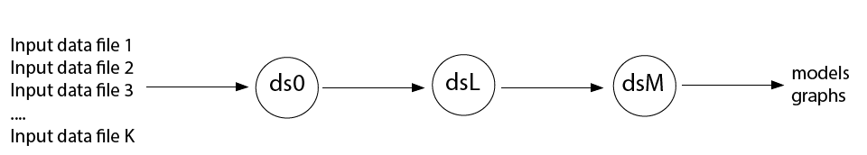

#### ds0

- verbatim input from raw files
- minimum or no processing
- “patient zero”

#### dsL

- span of the project
- subset of ds0
- long (L) or wide (W) data formats, respectively
- provides richer context
- invites future research
- experimentation

#### dsM

- model ready
- used for estimating models and producing graphs
- printed for display
- subset of dsL
- sometimes adds columns to service models

```
dsL <- ds0
```

during which `dsL` is created from `ds0` with a separate script.

```
./Scripts/Data/dsL.R
```

At this moment, in our workflow, however, we only at the stage of ds0. Letâ€™s take a momonet to explore the dataset `ds0` and recall some basic R vocabulary

```
class()
dim()
str()
summary()
table()
```

## Creating groups of variables

To help us handle ds0, which has way too many variables, we develop a meaningful set of variables that weâ€™d like to subset from ds0. It is convenient to distinguish two types:

#### Type 1 : Time Invariant variables - TI

- donâ€™t change with time

```r
# Time invariant variables
TIvars <- c(
  "Case", "PairID", "TwinID", "Zygosity", # Identification
  "BirthDate", "DeadDate", "Female", # Demographics
  "EducCat", "Educyrs", # Eduction
  "Dead", "DeadAge", "YTDead", # Mortality
  "TotDem", "DemEver", "DemType", "DemAge", "YTDem" # Dementia
)
# Small set of time invariant variables
TIsmall <- c("Case","PairID", "TwinID","Female")
```

#### Type 2 : Time Variant variables - TC

- their values DO change with time

```r
## Select the variables which names begin with ...
# names(ds0)[grep("^Marital", names(ds0))]
## Select the variables which names contain ...
# names(ds0)[grep("arital", names(ds0))]

TVMarital <- names(ds0)[grep("Marital", names(ds0))] # Marital status
TVCompAge <- names(ds0)[grep("CompAge", names(ds0))] # Computed Age
TVbmi <- names(ds0)[grep("bmi", names(ds0))] # Body Mass Index
TVepi_e <- names(ds0)[grep("epi_e", names(ds0))] # Systolic blood pressure
TVepi_n <- names(ds0)[grep("epi_n", names(ds0))]# Disystolic blood pressure
TVsbp <- names(ds0)[grep("sbp", names(ds0))] # Extraversion
TVdbp <- names(ds0)[grep("dbp", names(ds0))] # Neuroticism
TVdemtime <- names(ds0)[grep("demtime", names(ds0))] # diagnosed dementia
# collect all TV variables into one string
TVvars <- c(TVMarital, TVCompAge, TVbmi, TVepi_e, TVepi_n, TVsbp, TVdbp, TVdemtime)

# Small set of time variant variables
TVsmall <- c(TVMarital, TVCompAge, TVepi_e, TVepi_n )
```

Letâ€™s take a few minutes and understand how objects *TIvars* and *TVvars* were created, how they behave and how to use them.

Using these groups of variables and base subsetting [grammar](http://ialsa.github.io/tutorials/DM-with-dplyr.html#base-subsetting) we can select the variables weâ€™d like to select into our dsW stage.

```r
## Select the variables for your dsW
dsW <- ds0[,c(TIvars,TVvars)]
dim(dsW)
```

```
[1] 702  57
```

Naturally, we can change what variables get selected. Letâ€™s try to get a more manageable set.

## Reshaping the data

Notice that each occasion at which data was collected is hosted in separate variable/collumn. This is a characterist of data in **WIDE** format. However, most graph and model functions take data in **LONG** format. We transform the data with `melt` function of the `reshape2` package:

```r
#Transform the wide dataset into a long dataset
dsLong <- reshape2::melt(dsW, id.vars=TIsmall)  ## id.vars are Measured
dsLong <- dsLong[order(dsLong$Case, dsLong$variable), ] #Sort for the sake of visual inspection.
head(dsLong, 11)
```

```
     Case PairID TwinID Female  variable      value
1       1     28      1      0  Zygosity      2.000
703     1     28      1      0 BirthDate -21870.000
1405    1     28      1      0  DeadDate  11608.000
2107    1     28      1      0   EducCat      2.000
2809    1     28      1      0   Educyrs      6.000
3511    1     28      1      0      Dead      1.000
4213    1     28      1      0   DeadAge     91.660
4915    1     28      1      0    YTDead     -0.411
5617    1     28      1      0    TotDem        NaN
6319    1     28      1      0   DemEver      0.000
7021    1     28      1      0   DemType      4.000
```

Notice that ALL variables that change with time are stacked into two:  
- variable  
- value

However, some work may need to be done to clean up the new data

```r
# Create variable that counts time
dsLong$time <- stringr::str_sub(dsLong$variable,-1,-1)
# head(dsLong, 13)
# Remove the counter suffix from the "variable"
timepattern <- as.character(c(1:5))
for (i in timepattern){
  dsLong$variable <- gsub(pattern=i, replacement='', x=dsLong$variable)
}
head(dsLong, 11)
```

```
     Case PairID TwinID Female  variable      value time
1       1     28      1      0  Zygosity      2.000    y
703     1     28      1      0 BirthDate -21870.000    e
1405    1     28      1      0  DeadDate  11608.000    e
2107    1     28      1      0   EducCat      2.000    t
2809    1     28      1      0   Educyrs      6.000    s
3511    1     28      1      0      Dead      1.000    d
4213    1     28      1      0   DeadAge     91.660    e
4915    1     28      1      0    YTDead     -0.411    d
5617    1     28      1      0    TotDem        NaN    m
6319    1     28      1      0   DemEver      0.000    r
7021    1     28      1      0   DemType      4.000    e
```

Now we transform the data with the reverse function to `melt` in order to take the values of the column “variable” and make them into the names of the new individual variables. Let’s take a few minutes to interpret the syntax of the code and play with the options

```r
dsL <- dcast(dsLong, Case + PairID + TwinID + Female + time ~ variable, value.var = "value")
```

## Start Graphing

Now the data is ready to be graphed.

```r
# standard of the fontsize in plots
baseSize <- 11
# add  this theme to a ggplot to style it
themeLine <- ggplot2::theme_bw(base_size=baseSize) +
  ggplot2::theme(title=ggplot2::element_text(colour="gray20",size = baseSize+1)) +
  ggplot2::theme(axis.text=ggplot2::element_text(colour="gray40")) +
  ggplot2::theme(axis.title=ggplot2::element_text(colour="gray40")) +
  ggplot2::theme(panel.border = ggplot2::element_rect(colour="gray80")) +
  ggplot2::theme(axis.ticks.length = grid::unit(0, "cm")) +
  ggplot2::theme(text = element_text(size =baseSize+7))
```

Weâ€™ll use these style definitions in graphs.

We can start with a simple graph

```r
dsM <- dsL %>%
  dplyr::select(Case, PairID, TwinID, CompAge, epi_e, epi_n)
head(dsM, 11)
```

```
   Case PairID TwinID CompAge epi_e epi_n
1     1     28      1   91.25   NaN   NaN
2     1     28      1     NaN   NaN   NaN
3     1     28      1     NaN   NaN   NaN
4     1     28      1     NaN   NaN   NaN
5     1     28      1     NaN   NaN   NaN
6     1     28      1      NA    NA    NA
7     1     28      1      NA    NA    NA
8     1     28      1      NA    NA    NA
9     1     28      1      NA    NA    NA
10    1     28      1      NA    NA    NA
11    1     28      1      NA    NA    NA
```

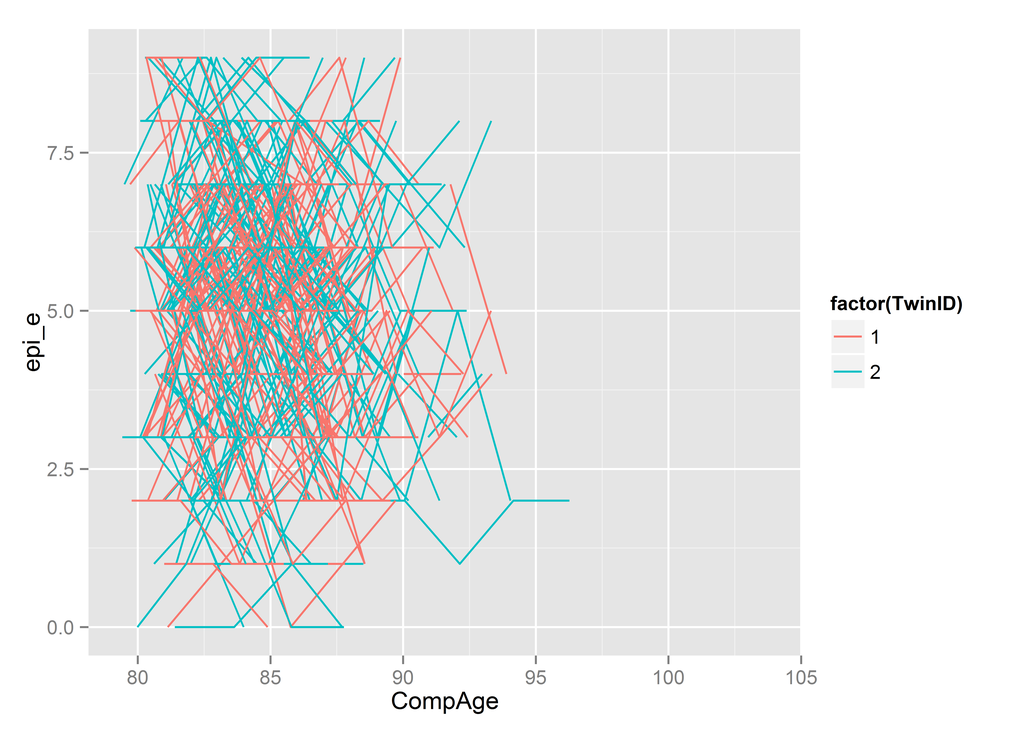

```r
p <- ggplot(dsM, aes(x=CompAge, group=Case, color=factor(TwinID)))
p <- p + geom_line(aes(y=epi_e))
p
```

and gradually evolve it into a more complex graph, as weâ€™ve done before

```r
dsM <- dsL %>%
  dplyr::select(Case, PairID, TwinID, CompAge, epi_e, epi_n) %>%
  dplyr::filter (TwinID %in% c(1,2))
head(dsM, 11)
```

```
   Case PairID TwinID CompAge epi_e epi_n
1     1     28      1   91.25   NaN   NaN
2     1     28      1     NaN   NaN   NaN
3     1     28      1     NaN   NaN   NaN
4     1     28      1     NaN   NaN   NaN
5     1     28      1     NaN   NaN   NaN
6     1     28      1      NA    NA    NA
7     1     28      1      NA    NA    NA
8     1     28      1      NA    NA    NA
9     1     28      1      NA    NA    NA
10    1     28      1      NA    NA    NA
11    1     28      1      NA    NA    NA
```

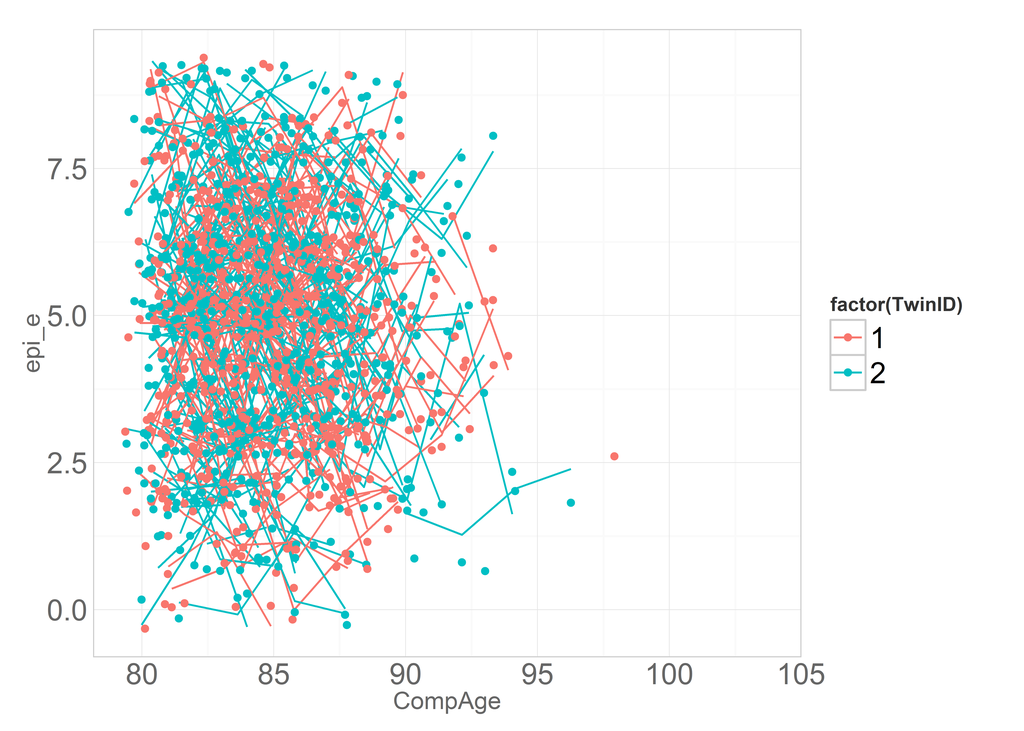

```r
p <- ggplot(dsM, aes(x=CompAge, group=Case, color=factor(TwinID)))
p <- p + geom_line(aes(y=epi_e),position="jitter")
p <- p + geom_point(aes(y=epi_e), position="jitter")
# p <- p + geom_line(aes(y=epi_n),position="jitter")
# p <- p + geom_point(aes(y=epi_n), position="jitter")
p <- p + themeLine
p
```

Next time, weâ€™ll take a look at graph production in detail.

[comments powered by Disqus](http://disqus.com)